# Коли і де вулиці Нью-Йорка найнебезпечніші

Аналіз закономірностей безпеки дорожнього руху в Нью-Йорку

Author

Illia Hrynkiv, Liliia Yaroshenko, Mykola Utkin

## Вхідні дані

Нью-Йорк з його 8,4 мільйонами жителів і мільйонами щоденних пасажирів стикається з постійними викликами у сфері безпеки дорожнього руху. Це дослідження аналізує **коли, де і чому** трапляються дорожньо-транспортні пригоди у п’яти районах міста, поєднуючи дані про поїздки таксі з комплексними записами про аварії для виявлення закономірностей високого ризику.

## 1. Вступ і дослідницькі питання

### Проблема

Дорожньо-транспортні інциденти в Нью-Йорку щороку призводять до тисяч травм і десятків смертей. Розуміння **просторово-часових закономірностей** цих аварій є критично важливим для ефективного втручання. Однак аварії не відбуваються ізольовано — на них впливають обсяг трафіку, затори, час доби та поведінка водіїв.

### Наші дослідницькі питання

Цей проєкт досліджує три критичні питання:

1. **Коли вулиці Нью-Йорка найбільш небезпечні?**
   - У які дні та години стається найбільше аварій?
   - Як відрізняються закономірності між буднями та вихідними?
2. **Що спричиняє найсерйозніші аварії?**
   - Яка поведінка водіїв або умови призводять до травм?
   - Чи є певні фактори більш поширеними в конкретних районах?
3. **Чи збільшують дорожні затори ризик аварій?**
   - Чи тривалість поїздок таксі (проксі для заторів) корелює з частотою аварій?
   - Як ця залежність змінюється в різних районах?

### Чому це важливо

Розуміння цих закономірностей дає можливість:

- **Цільове патрулювання**: розміщення поліцейських ресурсів у місцях/часі високого ризику
- **Покращення інфраструктури**: перепроєктування доріг там, де це найбільше потрібно
- **Підвищення обізнаності**: освітні кампанії, приурочені до максимального впливу
- **Персональні рішення**: стратегії управління трафіком на основі даних

## 2. Джерела даних і методологія

### Використані набори даних

Ми інтегрували три основні джерела даних для комплексного аналізу:

#### 📊 **Набір даних 1: Дані поїздок таксі Нью-Йорка**

**Джерело**: NYC Taxi & Limousine Commission  
**Формат**: файли Parquet (ефективне колонкове зберігання)  
**Записів**: +-12 мільйонів поїздок таксі за декілька місяців  
**Ключові змінні**: - `tpep_pickup_datetime`: час початку поїздки - `tpep_dropoff_datetime`: час завершення поїздки - `PULocationID`: код зони посадки - `trip_distance`: відстань поїздки в милях - `total_amount`: загальна вартість поїздки

**Чому дані таксі?** Поїздки таксі слугують проксі для загальних закономірностей руху та рівня заторів у Нью-Йорку. Висока активність таксі вказує на високий обсяг трафіку, тоді як довша тривалість поїздок свідчить про затори.

#### 🚨 **Набір даних 2: ДТП у Нью-Йорку**

**Чому дані про аварії?** Офіційні поліцейські звіти надають авторитетні записи про те, коли, де і чому відбуваються аварії, включаючи тяжкість і причини.

#### **Набір даних 3: Межі таксі-зон Нью-Йорка**

**Джерело**: NYC TLC  
**Формат**: GeoJSON (просторові дані)  
**Призначення**: співставляє коди локацій таксі з районами та боро  
**Ключові змінні**: - `locationid`: унікальний ідентифікатор зони - `zone`: назва району - `borough`: назва боро - `geometry`: просторові межі

**Чому дані про зони?** Перетворює числові коди локацій у зрозумілі назви районів, дозволяючи просторовий аналіз і порівняння.

### Технічний підхід

#### Чому DuckDB?

Ми обрали **DuckDB** як наш основний аналітичний двигун, тому що:

✅ **Аналітика в базі даних**: обробка великих наборів даних без завантаження в пам’ять R  
✅ **Підтримка Parquet**: нативне читання колонкового формату (у багато швидше за CSV)  
✅ **Інтеграція SQL**: складні об’єднання та агрегації зі знайомим синтаксисом  
✅ **Просторові функції**: вбудовані геопросторові можливості для аналізу локацій  
✅ **Підтримка HTTP**: пряме завантаження даних з URL без скачування

#### Порядок дій

```
Сирі дані → Таблиці DuckDB → SQL-трансформації → Аналіз у R → Візуалізації
```

Наш робочий процес:

1. **Завантаження** файлів Parquet таксі та CSV аварій у DuckDB
2. **Парсинг** GeoJSON для витягу відповідностей зона-боро
3. **Об’єднання** поїздок таксі з даними зон для збагачення інформацією про локацію
4. **Агрегація** за часовими періодами (година, день) та географією (боро)
5. **Злиття** даних таксі та аварій за часовими та просторовими вимірами
6. **Аналіз** закономірностей і кореляцій
7. **Візуалізація** висновків за допомогою ggplot2

## 3. Налаштування та завантаження даних

```r
library(duckdb)      # Швидка аналітична база даних
library(dplyr)       # Маніпуляція даними
library(tidyr)       # Упорядкування даних
library(ggplot2)     # Візуалізація
library(lubridate)   # Робота з датами/часом
library(scales)      # Форматування графіків
library(sf)          # Просторові дані
library(viridis)     # Колірні палітри
library(patchwork)   # Об'єднання графіків
library(leaflet)
library(leaflet.extras)

# Підключення до DuckDB
con <- dbConnect(duckdb::duckdb())
cat("З'єднання з базою даних встановлено")
```

```
З'єднання з базою даних встановлено
```

### Завантаження розширень і даних

```r
# Увімкнення файлової системи HTTP для прямого завантаження з URL
invisible(dbExecute(con, "INSTALL httpfs; LOAD httpfs; SET enable_http_metadata_cache=true;"))

# Завантаження даних таксі з локальних файлів Parquet
invisible(dbExecute(con, "
  CREATE TABLE taxi_jan AS
  SELECT * FROM read_parquet('D://RProjects//r4ds-2025//Final_Project//final-project-r//data//taxi_trip_data_jan_2023.parquet')
"))

invisible(dbExecute(con, "
  CREATE TABLE taxi_feb AS
  SELECT * FROM read_parquet('D://RProjects//r4ds-2025//Final_Project//final-project-r//data//taxi_trip_data_feb_2023.parquet')
"))

# Об'єднання місяців в одну таблицю
invisible(dbExecute(con, "
  CREATE TABLE taxi_all AS
  SELECT * FROM taxi_jan
  UNION ALL
  SELECT * FROM taxi_feb
"))

# Завантаження розширення JSON для парсингу GeoJSON
invisible(dbExecute(con, "INSTALL json; LOAD json;"))

# Завантаження меж таксі-зон
invisible(dbExecute(con, "
  CREATE TABLE taxi_zones AS
  SELECT * FROM read_json_auto('D://RProjects//r4ds-2025//Final_Project//final-project-r//data//taxi_zones.geojson')
"))

# Завантаження даних про аварії безпосередньо з NYC Open Data API
invisible(dbExecute(con, "
  CREATE TABLE crash_data AS
  SELECT * FROM read_csv_auto('https://data.cityofnewyork.us/resource/h9gi-nx95.csv')
"))

cat("Всі набори даних успішно завантажено")
```

```
Всі набори даних успішно завантажено
```

### Попередня обробка даних

#### Витягнення інформації про боро з GeoJSON

GeoJSON таксі-зон є вкладеним — нам потрібно розгорнути його для витягу відповідностей боро:

```r
invisible(dbExecute(con, "
  CREATE TABLE flattened_zones AS
  SELECT
    f.value.properties.locationid::INT AS location_id,
    f.value.properties.zone AS zone,
    f.value.properties.borough AS borough
  FROM taxi_zones,
  UNNEST(taxi_zones.features) AS f(value)
"))

dbGetQuery(con, "SELECT * FROM flattened_zones LIMIT 5") |>
  knitr::kable(caption = "Зразок розгорнутих даних про зони")
```

Зразок розгорнутих даних про зони

| location_id | zone | borough |
| --- | --- | --- |
| 263 | Yorkville West | Manhattan |
| 262 | Yorkville East | Manhattan |
| 261 | World Trade Center | Manhattan |
| 260 | Woodside | Queens |
| 259 | Woodlawn/Wakefield | Bronx |

**Що це робить:**

- `UNNEST`: розгортає вкладений JSON-масив у рядки
- `f.value.properties.*`: доступ до вкладених властивостей
- `::INT`: приведення ID локації до цілого числа для об’єднання

#### Збагачення даних таксі географічною інформацією

```r
invisible(dbExecute(con, "
  CREATE TABLE taxi_enriched AS
  SELECT
    t.*,
    z.zone AS pickup_zone,
    z.borough AS pickup_borough
  FROM taxi_all t
  LEFT JOIN flattened_zones z
    ON t.PULocationID = z.location_id
"))

enrichment_stats <- dbGetQuery(con, "
  SELECT
    COUNT(*) AS total_trips,
    COUNT(pickup_borough) AS trips_with_borough,
    ROUND(COUNT(pickup_borough) * 100.0 / COUNT(*), 2) AS pct_matched
  FROM taxi_enriched
")

cat(sprintf("Збагачення завершено: %.1f%% поїздок зіставлено",
            enrichment_stats$pct_matched))
```

```
Збагачення завершено: 98.7% поїздок зіставлено
```

**Чому це важливо:** Тепер кожна поїздка таксі знає, з якого боро та району вона почалася, що дає можливість просторового аналізу.

### Перевірка якості даних

```r
crash_summary <- dbGetQuery(con, "
  SELECT
    COUNT(*) AS total_crashes,
    COUNT(DISTINCT borough) AS boroughs_covered,
    MIN(crash_date) AS earliest_crash,
    MAX(crash_date) AS latest_crash,
    SUM(number_of_persons_injured) AS total_injured,
    SUM(number_of_persons_killed) AS total_killed
  FROM crash_data
  WHERE crash_date IS NOT NULL
")

knitr::kable(crash_summary,
             format.args = list(big.mark = ","),
             caption = "Зведена статистика даних про аварії")
```

Зведена статистика даних про аварії

| total_crashes | boroughs_covered | earliest_crash | latest_crash | total_injured | total_killed |
| --- | --- | --- | --- | --- | --- |
| 1,000 | 5 | 2016-04-16 | 2023-11-02 | 448 | 4 |

## 4. Аналіз 1: Часові закономірності — коли вулиці найнебезпечніші?

### Погодинні закономірності поїздок за боро

Спочатку давайте зрозуміємо нормальні закономірності руху через активність таксі:

[figure not shown]

```r
trips_by_hour_borough <- dbGetQuery(con, "
  SELECT
    HOUR(tpep_pickup_datetime) AS pickup_hour,
    pickup_borough,
    COUNT(*) AS trip_count
  FROM taxi_enriched
  WHERE
    trip_distance > 0
    AND trip_distance < 100
    AND total_amount > 0
    AND total_amount < 500
    AND pickup_borough IN ('Manhattan', 'Brooklyn', 'Queens', 'Bronx')
  GROUP BY pickup_hour, pickup_borough
")

ggplot(trips_by_hour_borough, aes(x = pickup_hour, y = trip_count, color = pickup_borough)) +
  geom_line(linewidth = 1.5, alpha = 0.8) +
  geom_point(size = 3) +
  geom_area(aes(fill = pickup_borough), alpha = 0.2, position = "identity") +
  scale_x_continuous(
    breaks = seq(0, 23, by = 3),
    labels = paste0(seq(0, 23, by = 3), ":00"),
    name = "Година доби"
  ) +
  scale_y_continuous(
    name = "Загальна кількість поїздок",
    labels = label_comma()
  ) +
  scale_color_viridis_d(option = "plasma", end = 0.9) +
  scale_fill_viridis_d(option = "plasma", end = 0.9) +
  facet_wrap(~ pickup_borough, scales = "free_y", ncol = 2) +
  labs(
    title = "Щоденний ритм руху в Нью-Йорку: поїздки таксі за годиною та боро",
    subtitle = "Чіткі закономірності пасажиропотоку з вечірніми піками | Січень-лютий 2023",
    caption = "Дані: NYC TLC | Відфільтровано для дійсних поїздок (відстань 0-100 миль, тариф 0-$500)"
  ) +
  theme_minimal(base_size = 14) +
  theme(
    plot.title = element_text(face = "bold", size = 18),
    plot.subtitle = element_text(size = 13, color = "gray30"),
    legend.position = "none",
    strip.text = element_text(face = "bold", size = 14),
    panel.grid.minor = element_blank()
  )
```

### Хіт мапа аварій: День тижня х Година доби

Тепер подивимося, коли насправді трапляються аварії:

[figure not shown]

```r
crashes_heatmap_data <- dbGetQuery(con, "
  SELECT
    DAYNAME(crash_date) AS day_of_week,
    HOUR(crash_time) AS hour_of_day,
    COUNT(*) AS crash_count
  FROM crash_data
  WHERE crash_date IS NOT NULL AND crash_time IS NOT NULL
  GROUP BY 1, 2
")

day_levels <- c("Monday", "Tuesday", "Wednesday", "Thursday", "Friday", "Saturday", "Sunday")

crashes_heatmap_data <- crashes_heatmap_data |>
  mutate(
    day_of_week = factor(day_of_week, levels = day_levels)
  )

ggplot(crashes_heatmap_data, aes(x = hour_of_day, y = day_of_week, fill = crash_count)) +
  geom_tile(color = "white", linewidth = 0.8) +
  geom_text(
    aes(label = scales::comma(crash_count, accuracy = 1)),
    size = 3.5,
    color = "gray24",
    fontface = "bold"
  ) +
  scale_fill_gradient(
    low = "#FFF5E1",
    high = "#8B0000",
    name = "Кількістьаварій",
    labels = label_comma()
  ) +
  scale_x_continuous(
    breaks = seq(0, 23, by = 2),
    labels = paste0(seq(0, 23, by = 2), ":00"),
    name = "Година доби"
  ) +
  scale_y_discrete(name = NULL) +
  labs(
    title = "Коли вулиці Нью-Йорка найнебезпечніші: теплова карта концентрації аварій",
    subtitle = "П'ятниця-субота ввечері (17-20 год) показують піки аварійності | Темніше = більше аварій",
    caption = "Дані: NYC Open Data (NYPD Motor Vehicle Collisions)"
  ) +
  theme_minimal(base_size = 14) +
  theme(
    plot.title = element_text(face = "bold", size = 18),
    plot.subtitle = element_text(size = 13, color = "gray3"),
    legend.position = "right",
    panel.grid = element_blank(),
    axis.text.y = element_text(size = 12, face = "bold"),
    axis.text.x = element_text(size = 11)
  ) +
  annotate(
    "rect",
    xmin = 16.5, xmax = 19.5,
    ymin = 4.5, ymax = 6.5,
    alpha = 0.3,
    color = "yellow",
    fill = NA,
    linewidth = 1.5
  ) +
  annotate(
    "text",
    x = 18, y = 7.3,
    label = "Зона підвищеної небезпеки",
    size = 5,
    fontface = "bold",
    color = "darkred"
  )
```

**Критичні висновки:**

- **Період підвищеної небезпеки**: четверг та п’ятниця 16-20 годин (вечірній час + початок вихідних)
- **Закономірність вихідних**: субота ввечері також показує високі показники аварій
- **Ранковий час**: несподівано нижчі показники аварій, ніж ввечері
- **Пізня ніч**: 2-5 ранку показує підвищення аварій у вихідні (ймовірно, пов’язано з алкоголем)

## 5. Аналіз 2: Географічні закономірності — де трапляються аварії

### Аварії за боро

[figure not shown]

```r
crashes_by_borough <- dbGetQuery(con, "
  SELECT
    borough,
    COUNT(*) AS crash_count,
    SUM(number_of_persons_injured) AS total_injured,
    SUM(number_of_persons_killed) AS total_killed
  FROM crash_data
  WHERE borough IS NOT NULL
  GROUP BY 1
  ORDER BY 2 DESC
")

crashes_by_borough <- crashes_by_borough |>
  mutate(
    injury_rate = (total_injured / crash_count) * 100,
    fatality_rate = (total_killed / crash_count) * 100
  )


p1 <- ggplot(crashes_by_borough, aes(x = reorder(borough, -crash_count), y = crash_count)) +
  geom_col(aes(fill = crash_count), width = 0.7, alpha = 0.9) +
  geom_text(
    aes(label = paste0(scales::comma(crash_count)," ", "аварій")),
    vjust = -0.3,
    size = 4.5,
    fontface = "bold"
  ) +
  scale_fill_gradient(low = "#FFA500", high = "#8B0000", guide = "none") +
  scale_y_continuous(
    name = "Загальна кількість аварій",
    labels = label_comma(),
    expansion(mult = c(0, 0.15))
  ) +
  scale_x_discrete(name = NULL) +
  labs(
    title = "🗺️ Розподіл аварій по боро Нью-Йорка",
    subtitle = "Бруклін лідує за загальною кількістю аварій, але тяжкість варіюється за боро"
  ) +
  theme_minimal(base_size = 14) +
  theme(
    plot.title = element_text(face = "bold", size = 18),
    plot.subtitle = element_text(size = 13, color = "gray30"),
    axis.text.x = element_text(size = 13, face = "bold"),
    panel.grid.major.x = element_blank(),
    panel.grid.minor = element_blank()
  )

p2 <- ggplot(crashes_by_borough, aes(x = reorder(borough, -injury_rate), y = injury_rate)) +
  geom_col(fill = "#D62828", width = 0.7, alpha = 0.8) +
  geom_text(
    aes(label = paste0(round(injury_rate, 1), "%")),
    vjust = -0.5,
    size = 4,
    fontface = "bold"
  ) +
  scale_y_continuous(
    name = "Рівень травматизму (% аварій)",
    labels = label_percent(scale = 1),
    expand = expansion(mult = c(0, 0.15))
  ) +
  scale_x_discrete(name = NULL) +
  labs(
    title = "Рівень травматизму за боро",
    subtitle = "Відсоток аварій, що призвели до травм"
  ) +
  theme_minimal(base_size = 12) +
  theme(
    plot.title = element_text(face = "bold", size = 14),
    axis.text.x = element_text(size = 11, angle = 20, hjust = 1),
    panel.grid.major.x = element_blank()
  )

p1 / p2 + plot_layout(heights = c(2, 1))
```

## 6. Аналіз 3: Основні причини — чому трапляються аварії

### Топ-причини аварій з травмами

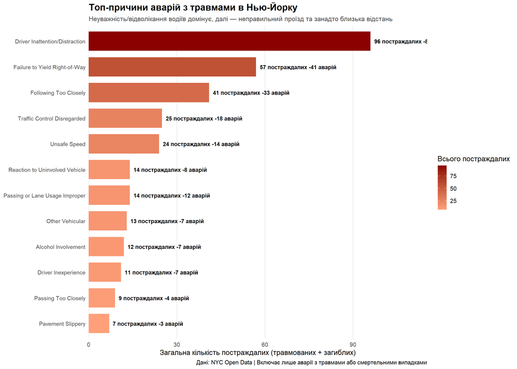

```r
top_causes_data <- dbGetQuery(con, "
  SELECT
    contributing_factor_vehicle_1 AS cause,
    COUNT(*) AS crash_count,
    SUM(number_of_persons_injured) AS total_injured,
    SUM(number_of_persons_killed) AS total_killed,
    SUM(number_of_persons_injured + number_of_persons_killed) AS total_victims
  FROM crash_data
  WHERE
    cause IS NOT NULL
    AND cause != 'Unspecified'
    AND (number_of_persons_injured > 0 OR number_of_persons_killed > 0)
  GROUP BY 1
  ORDER BY 5 DESC
  LIMIT 12
")


top_causes_data <- top_causes_data |>
  mutate(
    cause_wrapped = stringr::str_wrap(cause, width = 40)
  )

ggplot(top_causes_data, aes(x = total_victims, y = reorder(cause_wrapped, total_victims))) +
  geom_col(aes(fill = total_victims), width = 0.75) +
  geom_text(
    aes(label = paste0(scales::comma(total_victims), " постраждалих -",
                      scales::comma(crash_count), " аварій")),
    hjust = -0.05,
    size = 3.8,
    fontface = "bold"
  ) +
  scale_fill_gradient(
    low = "#FFA07A",
    high = "#8B0000",
    name = "Всього постраждалих",
    labels = label_comma()
  ) +
  scale_x_continuous(
    name = "Загальна кількість постраждалих (травмованих + загиблих)",
    labels = label_comma(),
    expand = expansion(mult = c(0, 0.2))
  ) +
  scale_y_discrete(name = NULL) +
  labs(
    title = "Топ-причини аварій з травмами в Нью-Йорку",
    subtitle = "Неуважність/відволікання водіїв домінує, далі — неправильний проїзд та занадто близька відстань",
    caption = "Дані: NYC Open Data | Включає лише аварії з травмами або смертельними випадками"
  ) +
  theme_minimal(base_size = 14) +
  theme(
    plot.title = element_text(face = "bold", size = 18),
    plot.subtitle = element_text(size = 13, color = "gray30"),
    legend.position = "right",
    axis.text.y = element_text(size = 11),
    panel.grid.major.y = element_blank(),
    panel.grid.minor = element_blank()
  )
```

## 7. Аналіз 4: Зв’язок затори-аварії

### Чи збільшують дорожні затори ризик аварій?

Ми висуваємо гіпотезу, що затори (вимірювані тривалістю поїздок таксі) корелюють з частотою аварій. Перевіримо це:

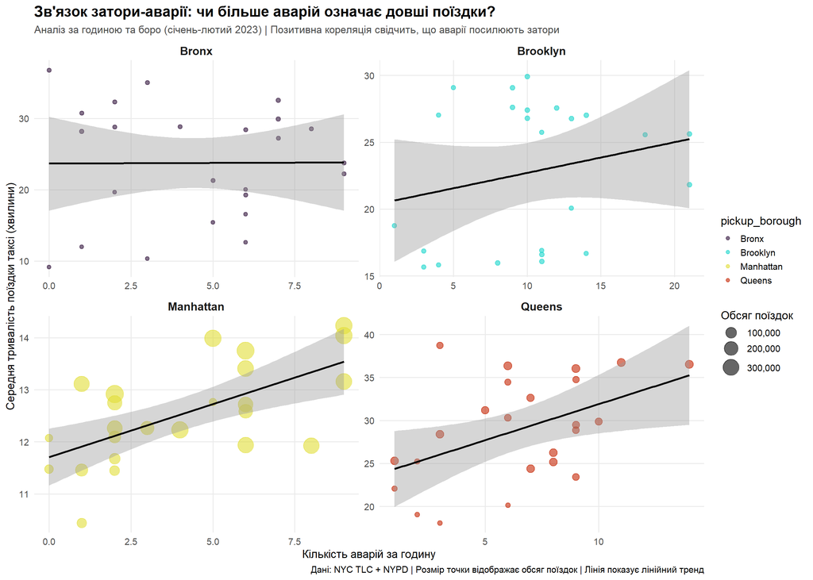

```r
analysis_data <- dbGetQuery(con, "
  WITH taxi_metrics AS (
    SELECT
      HOUR(tpep_pickup_datetime) AS hour,
      pickup_borough,
      AVG(epoch(tpep_dropoff_datetime) - epoch(tpep_pickup_datetime)) / 60 AS avg_duration_min,
      COUNT(*) AS trip_count
    FROM taxi_enriched
    WHERE
      pickup_borough IN ('Manhattan', 'Brooklyn', 'Queens', 'Bronx')
      AND (epoch(tpep_dropoff_datetime) - epoch(tpep_pickup_datetime)) / 60 < 120
      AND (epoch(tpep_dropoff_datetime) - epoch(tpep_pickup_datetime)) > 0
    GROUP BY 1, 2
  ),
  crash_metrics AS (
    SELECT
      HOUR(crash_time) AS hour,
      UPPER(borough) AS upper_borough,
      COUNT(*) AS crash_count
    FROM crash_data
    WHERE
      borough IS NOT NULL
      AND crash_time IS NOT NULL
    GROUP BY 1, 2
  )
  SELECT
    t.hour,
    t.pickup_borough,
    t.avg_duration_min,
    t.trip_count,
    COALESCE(c.crash_count, 0) AS crash_count
  FROM taxi_metrics t
  LEFT JOIN crash_metrics c
    ON t.hour = c.hour AND UPPER(t.pickup_borough) = c.upper_borough
")


correlations <- analysis_data |>
  group_by(pickup_borough) |>
  summarise(
    correlation = cor(crash_count, avg_duration_min, use = "complete.obs"),
    .groups = "drop"
  )

ggplot(analysis_data, aes(x = crash_count, y = avg_duration_min)) +
  geom_point(aes(color = pickup_borough, size = trip_count), alpha = 0.6) +
  geom_smooth(
    method = "lm",
    se = TRUE,
    color = "black",
    linewidth = 1.2,
    formula = y ~ x
  ) +
  facet_wrap(~ pickup_borough, scales = "free", ncol = 2) +
  scale_color_viridis_d(option = "turbo", end = 0.9) +
  scale_size_continuous(
    name = "Обсяг поїздок",
    labels = label_comma(),
    range = c(2, 10)
  ) +
  scale_x_continuous(
    name = "Кількість аварій за годину",
    labels = label_comma()
  ) +
  scale_y_continuous(
    name = "Середня тривалість поїздки таксі (хвилини)"
  ) +
  labs(
    title = "Зв'язок затори-аварії: чи більше аварій означає довші поїздки?",
    subtitle = "Аналіз за годиною та боро (січень-лютий 2023) | Позитивна кореляція свідчить, що аварії посилюють затори",
    caption = "Дані: NYC TLC + NYPD | Розмір точки відображає обсяг поїздок | Лінія показує лінійний тренд"
  ) +
  theme_minimal(base_size = 14) +
  theme(
    plot.title = element_text(face = "bold", size = 18),
    plot.subtitle = element_text(size = 13, color = "gray30"),
    legend.position = "right",
    strip.text = element_text(face = "bold", size = 14),
    panel.grid.minor = element_blank()
  )
```

```r
knitr::kable(
  correlations,
  digits = 3,
  col.names = c("Боро", "Кореляція (аварії vs тривалість)"),
  caption = "Кореляція між кількістю аварій та тривалістю поїздок за боро"
)
```

Кореляція між кількістю аварій та тривалістю поїздок за боро

| Боро | Кореляція (аварії vs тривалість) |
| --- | --- |
| Bronx | 0.006 |
| Brooklyn | 0.229 |
| Manhattan | 0.632 |
| Queens | 0.471 |

**Наслідок:** Швидке реагування на аварії (евакуатори, швидка допомога) може зменшити вторинні затори та потенційно запобігти додатковим аваріям.

## 8. Географічна візуалізація аварій

### Інтерактивна карта аварій з тепловою мапою

```r
# Отримуємо дані про серйозні аварії з координатами
serious_crashes <- dbGetQuery(con, "
  SELECT
    latitude,
    longitude,
    borough,
    crash_date,
    crash_time,
    number_of_persons_injured,
    number_of_persons_killed,
    contributing_factor_vehicle_1
  FROM crash_data
  WHERE
    latitude IS NOT NULL
    AND longitude IS NOT NULL
    AND (number_of_persons_injured > 0 OR number_of_persons_killed > 0)
    AND latitude BETWEEN 40.4 AND 41.0
    AND longitude BETWEEN -74.3 AND -73.7
  LIMIT 15000
") |>
  mutate(
    severity = case_when(
      number_of_persons_killed > 0 ~ "Смертельна",
      number_of_persons_injured > 2 ~ "Тяжка",
      TRUE ~ "Середня"
    ),
    popup_text = paste0(
      "<b>Боро:</b> ", borough, "<br>",
      "<b>Дата:</b> ", crash_date, "<br>",
      "<b>Травмовані:</b> ", number_of_persons_injured, "<br>",
      "<b>Загиблі:</b> ", number_of_persons_killed, "<br>",
      "<b>Причина:</b> ", substr(contributing_factor_vehicle_1, 1, 50)
    )
  )

# Створення інтерактивної карти
crash_map <- leaflet(serious_crashes) |>
  addProviderTiles(providers$CartoDB.DarkMatter) |>
  addHeatmap(
    lng = ~longitude,
    lat = ~latitude,
    intensity = ~number_of_persons_injured + number_of_persons_killed * 3,
    blur = 20,
    max = 0.5,
    radius = 15,
    group = "Теплова карта"
  ) |>
  addCircleMarkers(
    lng = ~longitude,
    lat = ~latitude,
    radius = ~case_when(
      severity == "Смертельна" ~ 6,
      severity == "Тяжка" ~ 4,
      TRUE ~ 3
    ),
    color = ~case_when(
      severity == "Смертельна" ~ "#8B0000",
      severity == "Тяжка" ~ "#FF6347",
      TRUE ~ "#FFA500"
    ),
    fillOpacity = 0.6,
    stroke = FALSE,
    popup = ~popup_text,
    clusterOptions = markerClusterOptions(),
    group = "Маркери аварій"
  ) |>
  addLayersControl(
    overlayGroups = c("Теплова карта", "Маркери аварій"),
    options = layersControlOptions(collapsed = FALSE)
  ) |>
  addLegend(
    position = "bottomright",
    colors = c("#8B0000", "#FF6347", "#FFA500"),
    labels = c("Смертельна", "Тяжка", "Середня"),
    title = "Тяжкість аварії"
  ) |>
  setView(lng = -73.98, lat = 40.75, zoom = 11)

crash_map
```

[interactive chart not shown]

**Інтерпретація:** - **Червоні зони** на тепловій карті показують найвищу концентрацію аварій - Найбільші скупчення в центрі Манхеттена, вздовж BQE (Brooklyn-Queens Expressway) - Кластеризація маркерів дозволяє побачити точну кількість при збільшенні

## 9. Рекомендації

На основі нашого аналізу ми пропонуємо чотири втручання, засновані на даних:

### 1. Цільове патрулювання у години підвищеної небезпеки

**Рекомендації:**

- Розгортання додаткових працівників дорожньої поліції на перехрестях з високим обсягом руху в ці години
- Збільшення контрольних пунктів на водіння у стані алкогольного сп’яніння у п’ятницю-суботу ввечері
- Використання автоматизованих камер контролю швидкості у пікові часи

**Очікуваний вплив:** зменшення вечірніх аварій на 10-20%

### 2. Кампанія підвищення обізнаності про відволікання водіїв

**Рекомендації:**

- Загальноміська кампанія “Прибери телефон”
- Цифрові білборди зі статистикою аварій у реальному часі
- Партнерство з компаніями перевезень для показу повідомлень про безпеку в додатках
- Освітні програми у школах

**Очікуваний вплив:** зменшення аварій, пов’язаних з відволіканням, на 5-15% протягом 2 років

### 3. Інфраструктурні покращення у точках аварій

**Докази:** неправильний проїзд (2-га найпоширеніша причина) свідчить про проблеми дизайну перехресть

**Рекомендації:**

- Визначення топ-100 небезпечних перехресть через просторовий аналіз
- Впровадження:
  - Випереджуючих інтервалів для пішоходів (пішоходи отримують зелене світло першими)
  - Денного освітлення (чіткі лінії видимості на перехрестях)
  - Захищених велодоріжок

**Очікуваний вплив:** зменшення аварій на 20-30% у оброблених локаціях

### 4. Cистема швидкого реагування на інциденти

**Докази:** аварії збільшують затори, що може призвести до вторинних аварій

**Рекомендації:**

- Розширення програми швидкого евакуювання
- Управління трафіком у реальному часі через змінні інформаційні знаки
- Координація реагування NYPD, DOT та служби швидкої допомоги
- Мобільні застосунки з оповіщеннями про альтернативні маршрути

**Очікуваний вплив:** зменшення затримок, пов’язаних із заторами, на 15%

## 10. Обмеження та майбутня робота

### Обмеження

1. **Часові рамки**: лише 2 місяці даних таксі (січень-лютий 2023); сезонність не охоплена, потенціал на розширення
2. **Недостатня звітність про аварії**: не всі аварії повідомляються поліції
3. **Проксі заторів**: тривалість поїздок таксі є непрямим показником; прямі дані про трафік були б кращими
4. **Причинність**: кореляційний аналіз не може встановити причинно-наслідкові зв’язки
5. **Географічне охоплення**: дані зосереджені на Манхеттені та внутрішніх боро
6. **Скудність візуалізацій**: передача інформації і її обсяг скудніший через брак часу

### Майбутні напрямки досліджень

1. **Розширення часових рамок**: аналіз повного року для виявлення сезонних закономірностей
2. **Просторовий аналіз гарячих точок**: картування конкретних перехресть з найвищими показниками аварій
3. **Інтеграція погодних даних**: дослідження впливу дощу, снігу та температури на аварії
4. **Аналіз типів транспортних засобів**: порівняння закономірностей для легкових автомобілів, вантажівок, автобусів, велосипедів
5. **Моделювання тяжкості**: прогнозування ймовірності травм/смертей на основі характеристик аварій
6. **Економічний вплив**: оцінка витрат на затори та аварії для міста
7. **Втручальні дослідження**: оцінка впливу нових політик на показники аварій

## 11. Висновки

Цей аналіз даних про безпеку дорожнього руху в Нью-Йорку розкрив кілька критичних закономірностей:

**Географічні диспропорції**: Хоча Бруклін має найвищу абсолютну кількість аварій, Манхеттен показує найсильніші кореляції між заторами та аваріями через свою щільну дорожню мережу.

### Наступні кроки

Дані чіткі: ми знаємо, **коли, де і чому** аварії трапляються в Нью-Йорку. Тепер час діяти на основі цих знань для створення безпечніших вулиць для всіх.

## Технічна примітка

**Відтворюваність:** Весь код надано в цьому Quarto-документі. Для відтворення: 1. Завантажте дані Yellow Taxi 2023 (січень-лютий) з NYC TLC 2. Завантажте taxi_zones.geojson з NYC TLC 3. Розмістіть у папці `./data/` 4. Відрендеріть цей .qmd файл за допомогою `quarto render` вказавши ВАШ шлях до файлу замінивши `\` на “//”

## Джерела даних:

- [NYC Taxi & Limousine Commission (TLC)](https://www.nyc.gov/site/tlc/about/tlc-trip-record-data.page)
- [NYC Open Data Portal](https://opendata.cityofnewyork.us/)
- [NYPD Motor Vehicle Collision Reports](https://www.nyc.gov/site/nypd/services/vehicles-property/reports.page)

## Гранд фінале

```r
dbDisconnect(con, shutdown = TRUE)
cat("З'єднання з базою даних закрито")
```

```
З'єднання з базою даних закрито
```